# TPC 8-Estatística computacional

João Francisco Botas, nº104782

15/10/2022

# Testes de Hipóteses

> Num inquérito sobre óculos de sol foram colocadas várias questões aos inquiridos. Para além de características sociodemográficas (sexo, idade e nível de educação), perguntou-se o tipo de óculos de sol que possuíam, quando tinham sido adquiridos, onde tinham sido adquiridos, quanto tinham custado e se eram da marca SoleMio(SM/RB).

> Para além destas questões, ainda foram colocadas outras que originaram a construção de um conjunto de indicadores, cada um numa escala contínua de 0 a 10 – fatores que influenciam a compra de óculos de sol.

> Para este TPC, irão apenas analisar duas questões: 1 e 2. O indicador “Importância do Preço na compra de óculos de sol” – variável Price;

> Os “Fatores que influenciam a compra de óculos de sol” são variáveis que assumem valores reais no intervalo 0-10, onde 0 corresponde a “nada importante” e 10 corresponde a “extremamente importante”.

Em primeiro lugar, irá utilizar-se a biblioteca *foreign* de modo a ler os dados do ficheiro RDS, através da função *readRDS*.

```r
library(foreign)
data_rds<-readRDS('Estudo_Oculos_Sol.rds')
```

> Responda a estas questões através da aplicação e interpretação de um teste de hipóteses adequado. Defina as populações em análise e os parâmetros de interesse. Siga os passos indicados nos slides (Etapas de um teste de hipóteses). Considere uma significância de referência de 5%.

## Exercício 1

> Será que a importância concedida ao preço está, em termos médios, acima do ponto intermédio da escala (i.e. 5)?

Para começar a analisar a pergunta vamos extrair os dados amostrais do nosso database, e guardar em variáveis para uso em outros *chunks* de código. Designemos a variável do problema:

$X$- importância do preço na compra de óculos de Sol

```r
media <- mean(data_rds$Price)
dp <- sd(data_rds$Price)
n <- length(data_rds$Price)
media
```

```
## [1] 6.62411
```

Com os valores retirados, passemos agora para escrever a hipótese nula e a hipótese alternativa, que serão:

$$H0\rightarrow \mu\le5\\ H1\rightarrow
\mu>5$$

O teste vai ser unilateral à direita, e irá utilizar-se o teste $N(0,1)$, no qual o valor da variância é desconhecido.

Será calculado o valor do quantil e, por conseguinte, construído um gráfico para observar as regiões crítica e não crítica, do problema em questão.

```r
significancia = 0.05
qnt <- qnorm(1-significancia)
cat("O valor correspondente ao quantil é de",qnt)
```

```
## O valor correspondente ao quantil é de 1.644854
```

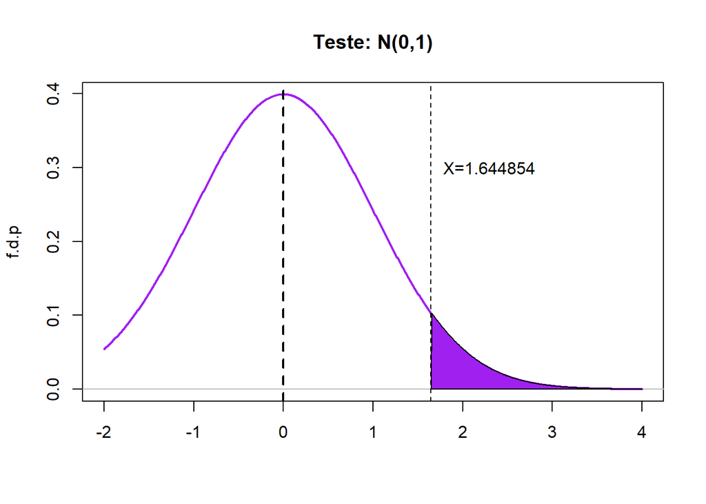

```r
eixo_x<-c(-2,4)
eixo_y<-c(0,dnorm(0))
plot(1,
     xlim = eixo_x, ylim = eixo_y,
     type = "n",
     main = "Teste: N(0,1)",
     ylab = "f.d.p", xlab = "")

abline(h = 0, col="grey")

curve(dnorm(x),
      from = eixo_x[1], to = eixo_x[2],
      n = 1000,
      col = "purple",
      lwd = 2,
      add=TRUE)

x1 <- seq(qnt,4,0.01)
y1 <- dnorm(x1)

coord_x <- c(x1,4,qnt)
coord_y <- c(0,y1,0)
polygon(coord_x,coord_y,col='purple')
abline(v=0,col = "black",lty = "dashed",lwd = 2)
abline(v=1.644854,col="black",lty = "dashed",lwd = 1)
text(2.3,.3,"X=1.644854")
```

Com os outputs acima, concluímos que a $RC=[1.645,+\infty[$ e que a $RNC= ]-\infty,1.645[$.

Agora, irá usar-se a expressão seguinte, de forma a concluir o valor do teste:

$$\frac{\overline X-\mu_0}{\frac{S´}{\sqrt
n}},\,onde\; o\;valor\; da\;variância(\sigma^2)\;,\, é\;
desconhecido$$

```r
H0 <- 5
exp1 <- (media - H0)/(dp/sqrt(n))
cat("O valor do teste de hipótese construído foi de:",exp1)
```

```
## O valor do teste de hipótese construído foi de: 38.12991
```

```r
t.test(data_rds$Price, alternative = "greater", mu = H0, conf.level = 1- significancia)
```

```
##
##  One Sample t-test
##
## data:  data_rds$Price
## t = 38.13, df = 639, p-value < 2.2e-16
## alternative hypothesis: true mean is greater than 5
## 95 percent confidence interval:
##  6.553947      Inf
## sample estimates:
## mean of x
##   6.62411
```

Após ter sido calculado o valor pretendido, $\approx$ 38.13, dá para concluir que iremos rejeitar a $H0$, pois o valor pertence ao intervalo: $RC=[1.645,+\infty[$, da região crítica. Outra forma de rejeitarmos a $H0$, é através do *p-value* obtido no *t.test*, onde $p-value\approx0\le\alpha=0.05$.

Por isso, pode dizer-se que a importância concedida pelas pessoas pertencentes à amostra, ao preço na compra de óculos de Sol, está acima de 5 (intervalo de 0 a 10), em termos médios.

## Exercício 2

> Será que homens e mulheres diferem, em termos médios, na importância concedida ao preço? (Suponha que as variâncias do preço nos dois grupos, embora sejam desconhecidas, podem ser consideradas iguais)

Pretende-se verificar se os homens e mulheres diferem na importância que dão ao preço. Para isso, será necessário realizar um teste de hipótese a fim de ter essa análise. Sabe-se que as variâncias são iguais, apesar de desconhecidas, e que a insignificância de referência é de $5%$.

Primeiro vamos retirar os valores amostrais para homens e mulheres e guardar em variáveis para, em seguida, fazermos o cálculo.

Sejam os acontecimentos:

$X_1$- importância concedida ao preço pelos homens

$X_2$- importância concedida ao preço pelas mulheres

```r
p_homens <- (data_rds$Price[data_rds$sex=="Male"])
p_mulheres <- (data_rds$Price[data_rds$sex=="Female"])

n1 <- length(p_homens)
m1 <- mean(p_homens)
dp1 <- sd(p_homens)
n2 <- length(p_mulheres)
m2 <- mean(p_mulheres)
dp2 <- sd(p_mulheres)
```

Foram criadas as variáveis com os valores, tanto para homens, como para mulheres.

Como queremos saber se a importância ao preço entre homens e mulheres difere, admitimos que a hipótese nula e a hipótese alternativa serão:
$$H0\rightarrow \mu_H=\mu_M \Leftrightarrow
\mu_H-\mu_M=0\\ H1\rightarrow \mu_H\neq\mu_M \Leftrightarrow
\mu_H-\mu_M\neq0$$
, onde $\mu_H$ e $\mu_M$ são os miu´s de homens e mulheres, respetivamente.

Como as hipóteses são igualdades, o teste é bilateral e terá dois limites, um negativo e um positivo. O teste que irá utilizar-se será o $t(n_1+n_2-2)$, pois assume-se que as variâncias tenham valores iguais, que sejam desconhecidas, e porque estamos a comparar miu, como explicado acima: $\mu_H-\mu_M$.

Agora, será desenhado um gráfico para observar a região critíca e não critíca tal como na *pergunta 1*, mas desta vez usando um teste bilateral.

```r
significancia=0.05
Lb <- -qnorm(1-significancia/2)
Ub <- qnorm(1-significancia/2)
RC <- c(Lb,Ub)
cat("O intervalo da região critíca é",RC)
```

```
## O intervalo da região critíca é -1.959964 1.959964
```

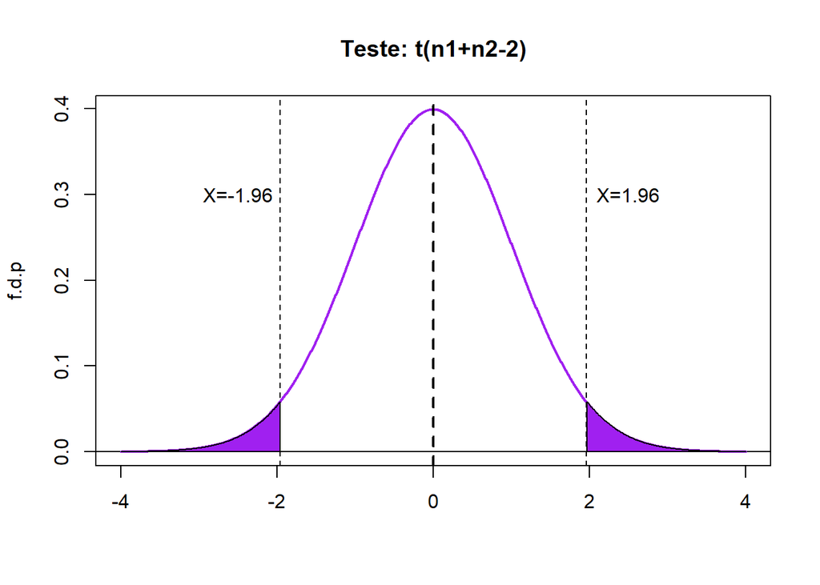

```r
eixo_x<-c(-4,4)
eixo_y<-c(0,dnorm(0))
plot(1,
     xlim = eixo_x, ylim = eixo_y,
     type = "n",
     main = "Teste: t(n1+n2-2)",
     ylab = "f.d.p", xlab = "")

abline(h = 0, col="black")

curve(dnorm(x),from = eixo_x[1], to = eixo_x[2],n = 1000,col = "purple",lwd = 2,add=TRUE)

x1 <- seq(-4,Lb,0.01)
y1 <- dnorm(x1)
x2 <- seq(Ub,4,0.01)
y2 <- dnorm(x2)

coord_x <- c(-4,x1,Lb)
coord_y <- c(0,y1,0)
coord_x2 <- c(x2,4,Ub)
coord_y2 <- c(0,y2,0)
polygon(coord_x,coord_y,col='purple')
polygon(coord_x2,coord_y2,col='purple')

abline(v=0,col = "black",lty = "dashed",lwd = 2)
abline(v=-1.96,col="black",lty = "dashed",lwd = 1)
abline(v=1.96,col="black",lty = "dashed",lwd = 1)
text(-2.5,.3,"X=-1.96")
text(2.5,.3,"X=1.96")
```

Com isto, concluímos que a $RC= ]-\infty,-1.96]\boldsymbol\cup[1.96,+\infty[$ e que a $RNC=[-1.96,1.96]$.

Irá realizar-se o teste, a fim de verificar se o seu valor está na região crítica, para tomar uma decisão relativamente à H0. Para isso, utilizar-se-á a seguinte fórmula:

$$\frac{(\overline{X_1}-\overline{X_2})-({\mu_1}-{\mu_2})_0}{\sqrt{\frac{1}{n_1}+\frac{1}{n_2}}{\sqrt{\frac{(n-1)s_1´^2+(n-2)s_2´^2}{n_1+n_2-2}}}}\;,\,onde\;\sigma_1^2=\sigma_2^2\;,\,em\;que\;ambas\;
são\;desconhecidas$$

```r
sdd=sqrt(n1^-1+n2^-1)*sqrt(((n1-1)*dp1^2+(n2-1)*dp2^2)/(n1+n2-2))
ET <- ((m1-m2))/sdd
cat("O valor do teste de hipótese é",ET)
```

```
## O valor do teste de hipótese é 1.982582
```

```r
t.test(p_homens,p_mulheres, alternative = "two.sided", mu = 0, var.equal = TRUE, conf.level = 1- significancia/2)
```

```
##
##  Two Sample t-test
##
## data:  p_homens and p_mulheres
## t = 1.9826, df = 638, p-value = 0.04784
## alternative hypothesis: true difference in means is not equal to 0
## 97.5 percent confidence interval:
##  -0.0224646  0.3597151
## sample estimates:
## mean of x mean of y
##  6.711584  6.542959
```

Foi calculado o valor do teste-t com a fórmula apresentada acima e com a função *t.test* e concluiu-se que o valor retornado foi de $\approx$ 1.983. Como o valor pertence ao intervalo: $RC= ]-\infty,-1.96]\boldsymbol\cup[1.96,+\infty[$, então rejeitamos a $H0$, para $\alpha=0.05$. Também podemos assumir a rejeição da $H0$ através do *p-value* calculado na função *t.test*, em que $p-value\approx 0.048\le \alpha=0.05$.

Assim, retira-se que a importância concedida ao preço na compra de óculos de Sol, difere entre homens e mulheres (é rejeitada a $H0$).